# The Truth of QWERTY

## Sunday, April 03, 2016

> The QWERTY arrangement was created in cooperation with educator Amos Densmore who studied the letter-pair frequency. It seemed if two type bars were near each other in the circle, they would tend to clash into each other when typed in succession. So, Densmore and Sholes figured the most common letter pairs such as "TH" and separated them at safe distances in the circle -- *Wally Hauck: Stop the Leadership Malpractice, Motivational Press (2015)*.

Mr. Amos Densmore was not an educator at that time in 1860's. He was then a proprietor of Densmore Oil Company at Meadville, Pennsylvania, which manufactured train cars for transporting petroleum (cf. [U. S. Patent No.53794](http://pdfpiw.uspto.gov/.piw?Docid=00053794&idkey=NONE)). Furthermore, "E" and "R" are placed near each other in the typebasket circle [as I mentioned before](http://yasuoka.blogspot.jp/2011/04/but-unique-and-lasting-feature-of.html), while "ER" is one of the most common letter pairs in English.

*posted by Koichi Yasuoka at [1:44 PM](http://yasuoka.blogspot.com/2016/04/the-qwerty-arrangement-was-created-in.html)* [0 comments](https://www.blogger.com/comment/fullpage/post/31607099/880000883705909395)

## Saturday, May 30, 2015

> E. Remington & Sons, a company that was then primarily known for manufacturing firearms, purchased Sholes's patent in 1873. After making a few additional mechanical improvements, like adding a Shift key to allow typists to switch between capital and lowercase letters, Remington began mass-producing typewriters that featured the QWERTY layout, with the intent of selling them to the business market, in 1874. -- *Josh Kaufman: The First 20 Hours, Portfolio / Penguin (2013)*.

Wrong. E. Remington & Sons manufactured the first commercial typewriter in September, 1873, but they did not purchase Sholes's patents (cf. *John A. Zellers: The Typewriter - A Short History on Its 75th Anniversary 1873-1948, Newcomen Society of England American Branch, New York (1948)*). The first typewriter with upper and lower case letters was Remington No.2 that was introduced in January, 1878, [as I mentioned before](http://yasuoka.blogspot.jp/2006/10/first-typewriters-could-print-only.html).

*posted by Koichi Yasuoka at [3:31 PM](http://yasuoka.blogspot.com/2015/05/e.html)* [0 comments](https://www.blogger.com/comment/fullpage/post/31607099/8265623353172052439)

## Friday, July 04, 2014

> In 1878, D. L. Scott-Brone opened the world's first typing school at 737 Broadway in New York. -- *Kendall Haven: 100 Greatest Science Inventions of All Time, Libraries Unlimited, Westport (2006)*.

Ah, well, do you mean Mr. Daniel L. Scott-Browne? If so, I know that Mr. Scott-Browne opened a typewriter section in his New York College of Standard Phonography, 737 Broadway, in 1878 (cf. *"Buy a Type-Writer", Browne's Phonographic Monthly, Vol.III, No.4 (April 1878), back-cover*). But Mr. William Ozmun Wyckoff had started his School of the Type Writer in Ithaca, New York, before 1878 (cf. *"Phonographic Institute and School of the Type Writer", The Type-Writer Magazine, Vol.2, No.1 (January 1878), p.18*), and Mr. Edward Payson Porter much before them in 1868 (see my [old page](http://yasuoka.blogspot.jp/2006/09/porters-telegraph-collegeno.html)).

*posted by Koichi Yasuoka at [5:37 PM](http://yasuoka.blogspot.com/2014/07/in-1878-d.html)* [0 comments](https://www.blogger.com/comment/fullpage/post/31607099/2074007476212329342)

## Saturday, July 14, 2012

> Sholes, Soule, and Glidden were frankly delighted. They determined to let their friends see at once what they had achieved, so they wrote hundreds of letters on their typewriter to correspondents far and near. Just one of these letters hit the bull's eye. It went to James Densmore, of Meadville, Pennsylvania, who took fire at this demonstration that a writing machine was about to supplant the pen. ... Densmore bluntly declared that it was good for nothing except to show that its underlying principles were sound. He urged the trio to proceed with further improvements, and promptly, for which he would advance all needed funds. At this stage of affairs, Soule and Glidden retired from the scene, leaving Sholes and Densmore in sole possession of the patent, and whatever harvest it might yield in time coming. -- *George Iles: Leading American Inventors, Henry Holt, New York (November 1912)*.

Although Mr. Samuel Willard Soulé left Milwaukee to New York before 1870, Mr. Carlos Glidden stayed in Milwaukee [as I mentioned before](http://yasuoka.blogspot.jp/2006/10/first-practical-typewriter-was.html). Mr. Glidden continued improving "Type Writer" and often claimed his contribution to it (cf. *Carlos Glidden: "The New Type Writer", Scientific American, Vol.27, No.9 (August 31, 1872), p.132, l.2*). He deceased on March 11, 1877, and his latest contribution was patented as [U. S. Patent No.470874](http://patimg2.uspto.gov/.piw?docid=US000470874&IDKey=NONE) after his death.

*posted by Koichi Yasuoka at [10:35 PM](http://yasuoka.blogspot.com/2012/07/sholes-soule-and-glidden-were-frankly.html)* [0 comments](https://www.blogger.com/comment/fullpage/post/31607099/4971708868034698908)

## Wednesday, January 25, 2012

> The original typewriter, invented by Christopher Latham Sholes in 1868, never imagined that typewriting would be faster than handwriting, which is usually around 20 words per minute or less. The machine was designed in an alphabetical fashion and when a typist pressed a key, a lever would come up with an inked letter and leave the letter's impression on the paper. The problem was that the levers jammed easily so Sholes obtained a list of the most common letters used in English, and reconfigured the keyboard by splitting up those keys to slow down typing. Think about that. The QWERTY design is configured to slow you down. -- *Patricia Harmon: The Mind of an Inventor, Strategic Book Publishing, Dunham (2010)*.

An inked letter? No. In the early Type-Writer Mr. Christopher Latham Sholes used the carbon paper to make the impression, and then used the inked ribbon. Furthermore, he never intended to slow down typing. In fact "th", most-commonly-typed letter sequence in English, is placed adjacently on the QWERTY keyboard. "The QWERTY design is configured to slow you down" is nothing but a hoax by Mr. Robert Parkinson, [as I mentioned before](http://yasuoka.blogspot.com/2006/08/before-going-on-with-history-of-dr.html).

*posted by Koichi Yasuoka at [8:23 AM](http://yasuoka.blogspot.com/2012/01/original-typewriter-invented-by.html)* [0 comments](https://www.blogger.com/comment/fullpage/post/31607099/1457548801969174017)

## Wednesday, August 10, 2011

> On July 25, 1888, two men brought their typewriters to Cincinnati for what might be called the first "speed trials" of the information age. ... The first of the competitors was Louis Taub. A champion of the old school, Taub used only two fingers from each hand to operate his double keyboard Caligraph, and type by reading a line or two of the copy and then transcribing them. His opponent, Frank E. McGurrin, was of the new school. The key to his technique was that he used not only all ten of his fingers on his Remington No.1, but that he typed "blind": having memorized the keyboard, McGurrin relied on his sense of touch alone to ensure the accuracy of his transcription. -- *Christopher Keep: "Blinded by the Type", Ninteenth-Century Contexts, Vol.23, No.1 (June 2001), pp.149-173*.

His name was Louis Traub, not Taub, and he was an eight-finger typist on Caligraph No.2 [as I mentioned before](http://yasuoka.blogspot.com/2006/08/mrs-l.html). At that time Mr. Frank Edward McGurrin was an all-finger typist on Remington No.2, not Remington No.1 (cf. *"McGurrin's Record", The Deseret News, Vol.37, No.36 (September 19, 1888), p.1, l.2*). Furthermore, the typewriter contest on July 25, 1888, at Cincinnati was not the first one ever. At least, a typewriter contest at New York had been reported in April, 1887 (cf. *"About Women", Logansport Daily Pharos, 12th Year, No.267 (April 2, 1887), p.3, l.4*).

*posted by Koichi Yasuoka at [5:24 PM](http://yasuoka.blogspot.com/2011/08/on-july-25-1888-two-men-brought-their.html)* [0 comments](https://www.blogger.com/comment/fullpage/post/31607099/8907122588348967307)

## Thursday, June 23, 2011

> Around 1875, the first keyboards for typewriters were created and their keys were alphabetically arranged. It is said that Christopher Latham Shore, an early inventor of the typewriter, changed them to the QWERTY configuration to make it more difficult to type fast and jam the key bars. -- *M. Castillo: "QWERTY, @, &, #", American Journal of Neuroradiology, Vol.32, No.4 (April 2011), pp.613-614*.

His name was Christopher Latham Sholes, not Shore. In the 1860's he used alphabetically-arranged keyboards, but in April, 1870, he moved to non-alphabetical. Furthermore, he never intended to make it more difficult to type fast on the QWERTY keyboard (cf. *Koichi Yasuoka and Motoko Yasuoka: "On the Prehistory of QWERTY", ZINBUN, No.42 (March 2011), pp.161-174*).

*posted by Koichi Yasuoka at [1:58 PM](http://yasuoka.blogspot.com/2011/06/around-1875-first-keyboards-for.html)* [0 comments](https://www.blogger.com/comment/fullpage/post/31607099/4464469671732068215)

## Monday, May 02, 2011

> The first *kana* typewriter was produced in 1923 by the Underwood Typewriter Company at the urging of Yamashita Yoshitarō, a former diplomat and director of Sumitomo Bank who founded the current Kanamojikai (Kana Writing Society) in 1920. The method for assigning *kana* to typewriter keys was based on the same principle that had been employed in the design of the now standard English (or "QWERTY") keyboard, on which frequently used letters were purposely put in distant locations. -- *J. Marshall Unger: Literacy and Script Reform in Occupation Japan, Oxford University Press, New York (1996)*.

Totally false. In February, 1923, Mr. Burnham Coos Stickney of Underwood Typewriter did not arrange the *kana* keyboard in such way. He mainly followed *50-on* order, placing アイウエオ on the upper rows, カキクケコ at the center, then サシスセソ at its left, タチツテト at next, and so forth (cf. [U. S. Patent No.1549622](http://patimg1.uspto.gov/.piw?docid=01549622&IDKey=NONE)). Furthermore, it was not the first *kana* typewriter. For example, in September, 1899, Mr. Teijiro Kurosawa of Elliott & Hatch Book Typewriter made his own *kana* typewriter (cf. *Nihon-ji no Typewriter, Jiji Shimpo, No.5663 (September 3, 1899), p.6*). Additionally, frequently-used letter sequences in English, such as "th", were not put in distant locations on the QWERTY keyboard, [as I mentioned before](http://yasuoka.blogspot.com/2007/07/in-late-1800s-there-was-no-standard.html).

*posted by Koichi Yasuoka at [10:36 AM](http://yasuoka.blogspot.com/2011/05/first-kana-typewriter-was-produced-in.html)* [0 comments](https://www.blogger.com/comment/fullpage/post/31607099/6702610481129238512)

## Wednesday, April 27, 2011

> Please explain to Mr. Harrington that you can make a note form printer at short notice, and that (working print a type wheel) it must print faster & much better than can possibly be done by the levers or arms plan of Sholes. My idea is that it is a decided object for us to have the control of the Sholes machine, provided it costs little or nothing--but if not, not.--and of course, relying upon your inventive head to work us through when and as may be necessary. -- *D. H. Craig to Edison, a letter dated January 31, 1871*.

In September, 1870, Mr. Christopher Latham Sholes visited New York to meet Mr. Daniel Hutchins Craig and Mr. George Harrington. He demonstrated his Type-Writer, but it was severely criticized by one of Mr. Harrington's partners, Mr. Thomas Alva Edison. Thus Mr. Craig decided to have Mr. Sholes and Mr. Edison to compete for a "note form printer". As Mr. Edison could not complete his type-wheel "universal printer" by the end of September, 1871, Messrs. Craig and Harrington decided to adopt Mr. Sholes' Type-Writer (cf. *Koichi Yasuoka and Motoko Yasuoka: "On the Prehistory of QWERTY", ZINBUN, No.42 (March 2011), pp.161-174*).

*posted by Koichi Yasuoka at [11:19 AM](http://yasuoka.blogspot.com/2011/04/please-explain-to-mr.html)* [0 comments](https://www.blogger.com/comment/fullpage/post/31607099/1300605251734491670)

## Friday, April 22, 2011

> **QWERTY**  
> The keyboard on the first practical typewriter, while simpler, was identcal in arrangement to the keyboard on a twenty-first century laptop. A girl learning touch typing in 1880 took much the same course as an aspiring typist today. -- *Joseph R. Conlin: The American Past, Vol.2, 9th edition, Wadsworth Cengage Learning, Boston (2011)*.

No. The first typewriter had QWERTY keyboard, but its arrangement was different in keys M, C, and X, from QWERTY nowadays. So, in the 1880's, the fingerings of typings were much different from today. For example, Mr. William Ozmun Wyckoff of Ithaca, New York, taught his six-finger typing method to his shorthand pupils at Phonographic Institute, just as follows:

> | 1 | 1 | 2 | 2 |
> | --- | --- | --- | --- |
> | t | h | i | s |
> | L | R | R | L |

> | 3 | 3 | 1 | 1 | 2 | 1 | 2 |
> | --- | --- | --- | --- | --- | --- | --- |
> | m | a | c | h | i | n | e |
> | R | L | L | R | R | R | L |

> | 2 | 3 | 1 |
> | --- | --- | --- |
> | w | a | s |
> | L | L | L |

> | 3 | 3 | 1 | 2 |
> | --- | --- | --- | --- |
> | m | a | d | e |
> | R | L | L | L |

After the keys M, C, and X were moved to the places as seen today, [Mrs. Elizabeth Margaret Vater Longley](http://yasuoka.blogspot.com/2008/04/margaret-elizabeth-vater-longley-1831.html) started to teach her eight-finger typing method at her own school, the Cincinnati Shorthand and Type-Writer Institute:

> | 1 | 1 | 2 | 3 |
> | --- | --- | --- | --- |
> | t | h | i | s |
> | L | R | R | L |

> | 1 | 4 | 2 | 1 | 2 | 1 | 3 |
> | --- | --- | --- | --- | --- | --- | --- |
> | m | a | c | h | i | n | e |
> | R | L | L | R | R | R | L |

> | 3 | 4 | 3 |
> | --- | --- | --- |
> | w | a | s |
> | L | L | L |

> | 1 | 4 | 2 | 3 |
> | --- | --- | --- | --- |
> | m | a | d | e |
> | R | L | L | L |

[Mr. Frank Edward McGurrin](http://yasuoka.blogspot.com/2009/04/frank-r.html) of Salt Lake City typed the same sentence as follows:

> | 1 | 1 | 2 | 3 |
> | --- | --- | --- | --- |
> | t | h | i | s |
> | L | R | R | L |

> | 2 | 4 | 1 | 1 | 2 | 1 | 2 |
> | --- | --- | --- | --- | --- | --- | --- |
> | m | a | c | h | i | n | e |
> | R | L | L | R | R | R | L |

> | 3 | 4 | 3 |
> | --- | --- | --- |
> | w | a | s |
> | L | L | L |

> | 2 | 4 | 1 | 2 |
> | --- | --- | --- | --- |
> | m | a | d | e |
> | R | L | L | L |

They used their contemporary typing methods at that time, which were different from today, [as I mentioned before](http://kanji.zinbun.kyoto-u.ac.jp/~yasuoka/publications/PreQWERTY.html).

*posted by Koichi Yasuoka at [1:01 PM](http://yasuoka.blogspot.com/2011/04/qwerty-keyboard-on-first-practical.html)* [0 comments](https://www.blogger.com/comment/fullpage/post/31607099/7479158698349032740)

## Monday, April 18, 2011

> A big step toward adoption of the QWERTY keyboard as the industry standard came in a typing contest held in Cincinnati in 1888, where Frank McGurrin (who used a QWERTY keyboard) won a decisive victory over Louis Taub (who used an alternative keyboard). McGurrin's victory had more to do with the fact that he was one of the first "touch typists" (whereas Taub used the "hunt-and-peck" method). -- *Bruno Dyck, Mitchell J. Neubert: Management: Current Practices and New Directions, Houghton Mifflin Harcourt Publishing, Boston (2010)*.

His name was Louis Traub, not Taub, and he was an eight-finger typist on Caligraph No.2 [as I mentioned before](http://yasuoka.blogspot.com/2006/08/mrs-l.html). Furthermore, Mr. Frank Edward McGurrin was beaten by Miss Mae E. Orr, who was a two-finger hunt-and-peck typist, in another typing contest held in Toronto on August 13, 1888 (cf. *"Canadian Shorthand Society", The Cosmopolitan Shorthander, Vol.9, No.8 (September 1888), pp.210-215*). Well, how Mr. McGurrin's defeat had more or less to do with the fact?

*posted by Koichi Yasuoka at [12:11 PM](http://yasuoka.blogspot.com/2011/04/big-step-toward-adoption-of-qwerty.html)* [0 comments](https://www.blogger.com/comment/fullpage/post/31607099/36277372422974905)

## Tuesday, April 12, 2011

> But the unique and lasting feature of the Sholes & Glidden was the QWERTYUIOP keyboard layout which is in worldwide use today in spite of being an illogical arrangement adopted merely in order to avoid adjacent typebars clashing. -- *Duncan James: Old Typewriters, Shire Publications, Princes Risborough (1993)*.

Adjacent typebars? Well, in fact, any two typebars of QWERTYUIOP were not adjacent in the typebar basket of Sholes & Glidden Type-Writer. There was a typebar for numeral 2 between Q and W. Numerals 3 and 4 between W and E. 5 between E and R. 6 between R and T. 7 between T and Y. 8 between Y and U. 9 between U and I. "-" between I and O. And "," between O and P. Any rearrangement of QWERTYUIOP could avoid their typebars to be placed adjacently. Mr. James, you cannot explain how QWERTYUIOP was made, telling "merely in order to avoid adjacent typebars clashing" (cf. *Koichi Yasuoka and Motoko Yasuoka: "On the Prehistory of QWERTY", ZINBUN, No.42 (March 2011), pp.161-174*).

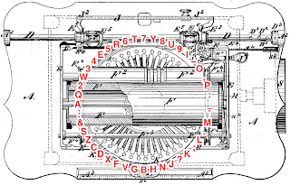

*posted by Koichi Yasuoka at [2:23 PM](http://yasuoka.blogspot.com/2011/04/but-unique-and-lasting-feature-of.html)* [0 comments](https://www.blogger.com/comment/fullpage/post/31607099/2304374952965749893)

## Friday, January 14, 2011

> Demonstrations of typing speed were a source of public entertainment. In 1888 a well-publicized contest was held in Cincinnati that pitted Louis Taub, who had been traveling in the east and billing himself as the world's fastest typist, against Francis McGurrin, a typist from Salt Lake City. Taub used a rival machine with a rival keyboard arrangement, the Calligraph, and a hunt-and-peck method of typing. -- *Stan Liebowitz and Stephen E. Margolis: "Policy and Path Dependence", Regulation, Vol.18, No.3 (Summer 1995), pp.33-41*.

Well, Prof. Liebowitz and Prof. Margolis, you seem to have mistaken both competitor's names, Mr. Louis Traub and Mr. Frank Edward McGurrin, at [the typewriter competition on July 25, 1888](http://yasuoka.blogspot.com/2006/08/salt-lake-city-utah-dec.html). Mr. Traub had visited the 1887 Indiana State Fair in Indianapolis, where he exhibited his typing skill on Caligraph No.2 with a blank keyboard (cf. *History of Cincinnati and Hamilton County, Ohio; S. B. Nelson, Cincinnati (1894)*). Mr. Traub was an eight-finger typist on Caligraph No.2 (not Calligraph) [as I mentioned before](http://yasuoka.blogspot.com/2006/08/mrs-l.html).

*posted by Koichi Yasuoka at [11:34 AM](http://yasuoka.blogspot.com/2011/01/demonstrations-of-typing-speed-were.html)* [0 comments](https://www.blogger.com/comment/fullpage/post/31607099/3606052908887641592)

## Tuesday, January 11, 2011

> This typewriter is one of those manufactured by E. Remington & Sons under the agreement entered into on March 1st, 1873. ... Densmore and Sholes conceived the idea of arranging the keyboard so that the letters which most frequently occurred together were placed as far as possible apart in the type-basket. Amos Densmore asked his son-in-law, who was at the time superintendent of schools in Western Pennsylvania, to make a list of the frequency of juxtaposition with which the letters in written English occurred, and this list formed the basis on which the "Universal" keyboard was ultimately arranged. -- *G. Tilghman Richards: The History and Development of Typewriters, His Majesty's Stationery Office, London (1938)*.

Mr. Amos Densmore had no son-in-law in 1873. His oldest daughter, Miss Blanche Densmore, married with Mr. Charles Alphonso Curtis in Meadville, Pennsylvania on January 7, 1875, thereafter, Mr. Amos Densmore got his son-in-law. Mr. Amos Densmore couldn't ask his son-in-law anything about written English before the first "Sholes & Glidden Type-Writer" was shipped out in April, 1874. His brother, Mr. James Densmore, either, had no son-in-law at that time [as I mentioned before](http://yasuoka.blogspot.com/2006/09/in-their-innocence-sholes-and-his.html).

*posted by Koichi Yasuoka at [6:16 PM](http://yasuoka.blogspot.com/2011/01/this-typewriter-is-one-of-those.html)* [2 comments](https://www.blogger.com/comment/fullpage/post/31607099/6711884236194911698)

## Thursday, June 10, 2010

> Yes, there is a Sholes and Glidden in the collection. I've seen them before, but it is still a semi-religious experience. What struck me this time was the small diameter of the typebasket compared to the body of the machine, the tiny type, and the big keys topped with glossy, convex glass. This is an early S&G (serial number 225), designed to be used with a foot treadle for the carriage return. Every S&G has its own story, and this one is distinguished by a surprising stencil.

[figure not shown]

> -- *Richard Polt: "A Visit to the IBM Collection", ETCetera, No.59 (September 2002), pp.7-9*

If its serial number is truely 225, it is one of the machines which were dispatched to the Western Union Telegraph Company, Chicago, from E. Remington & Sons in the summer of 1874. The machines were used to receive and write down Morse telegraphs in the telegraph stations, and then, in between 1878 and 1881, they were replaced by new machines "Remington No.2". Some of them were possibly resold by the Western Electric Manufacturing Company. In my opinion the stencil and decoration were wrote at the time of reselling around 1880 or after.

*posted by Koichi Yasuoka at [10:36 AM](http://yasuoka.blogspot.com/2010/06/yes-there-is-sholes-and-glidden-in.html)* [2 comments](https://www.blogger.com/comment/fullpage/post/31607099/7505436709094641280)

## Friday, February 26, 2010

> The father of the typewriter was Christopher Latham Sholes, who ran headlong into an unforeseen problem. His early machines, slower than the typists' fingers, kept jamming. To correct this problem Sholes carefully devised the QWERTY keyboard. He spread the most common letters---E, T, O, A, N, I---all over the board and ensured that frequent combinations such as "ed" had to be struck by the same finger so that the machine would not jam. In other words, the QWERTY keyboard was invented to slow down typing speed. -- *William Hoffer: "The Dvorak Keyboard: Is It Your Type?", Nation's Business, Vol.73, No.8 (August 1985), pp.38-40.*

The most frequent combination in English is "th", which ordinary has to be struck by different fingers. The second is "er"+"re", and the third is "he"+"eh". "ed" is less than half for "th" (cf. *Roy T. Griffith: "The Minimotion Typewriter Keyboard", Journal of the Franklin Institute, Vol.248, No.5 (November 1949), pp.399-436*). "To slow down typing speed" is nothing but a hoax of Mr. Robert Parkinson, [as I mentioned before](http://yasuoka.blogspot.com/2006/08/before-going-on-with-history-of-dr.html).

*posted by Koichi Yasuoka at [1:39 PM](http://yasuoka.blogspot.com/2010/02/father-of-typewriter-was-christopher.html)* [0 comments](https://www.blogger.com/comment/fullpage/post/31607099/103611250591627583)

## Friday, February 12, 2010

> When mechanical typewriters were developed, touch-typists had to be slowed down by inefficient keyboard layouts because their increasing dexterity would continually jam the mechanically slow machines. One of the most inefficient designs (by Christopher Scholes in 1873) was the QWERTY layout, which was adopted and mass-produced by Remington. More typists accordingly learned on the QWERTY layout, more companies therefore adopted the same layout, and a virtually unbreakable lock-in of the QWERTY keyboard resulted.-- *Mark Mason: "Making Educational Development and Change Sustainable", International Journal of Educational Development, Vol.29, No.2 (March 2009), pp.117-124*.

"Touch-typists had to be slowed down" is nothing but a hoax by Mr. Robert Parkinson, [as I mentioned before](http://yasuoka.blogspot.com/2006/08/before-going-on-with-history-of-dr.html). The QWERTY keyboard was invented by Mr. Christopher Latham Sholes, not Scholes (cf. [U. S. Patent No.207559](http://patimg2.uspto.gov/.piw?docid=00207559&IDKey=NONE)). E. Remington & Sons adopted QWERTY keyboard, but the other typewriter companies, including [Caligraph](http://www.typewritermuseum.org/collection/brands/index.php3?machine=caligr&cat=ku) and [Hammond](http://www.typewritermuseum.org/collection/brands/index.php3?machine=hammond1&cat=ks), offered their own keyboard arrangements, not QWERTY, in the 1880's.

*posted by Koichi Yasuoka at [1:16 PM](http://yasuoka.blogspot.com/2010/02/when-mechanical-typewriters-were.html)* [0 comments](https://www.blogger.com/comment/fullpage/post/31607099/338046883008778576)

## Monday, September 07, 2009

> Sholes had just received a patent for a third invention, an improved pager, when Carlos Glidden, a fellow tinkerer at Kleinsteuber's shop, showed him an article in an 1867 *Scientific American* describing "a machine by which it is assumed that a man may print his thoughts twice as fast as he can write them and with the advantage of legibility, compactness, and neatness of print [invented by a] Mr. Pratt of Alabama. -- *Cynthia Monaco: "The Difficult Birth of the Typewriter", American Heritage of Invention & Technology, Vol.4, No.1 (Spring/Summer 1988), pp.10-21*.

*Scientific American* issued Mr. John Pratt's article on July 6, 1867 (cf. *"Type Writing Machine", Scientific American, Vol.17, No.1 (July 6, 1867), p.3, l.1*). The third invention of Mr. Christopher Latham Sholes, titled "Improvement in Numbering-Machines", was patented on November 13, 1866 (cf. [U. S. Patent No.59675](http://patimg2.uspto.gov/.piw?Docid=00059675&idkey=NONE)). It's impossible for Mr. Carlos Glidden to show the 1867 article to Mr. Sholes in 1866.

In fact Mr. Sholes started the development of Type-Writer when he received his second patent, titled "Improved Shoe-Blush", on August 14, 1866 (cf. [U. S. Patent No.57168](http://patimg2.uspto.gov/.piw?Docid=00057168&idkey=NONE)). In the same patent issue Mr. Sholes should have found a patent of Mr. Abner Peeler, titled "Machine for Writing and Printing" (cf. [U. S. Patent No.57182](http://patimg2.uspto.gov/.piw?Docid=00057182&idkey=NONE)).

*posted by Koichi Yasuoka at [11:14 AM](http://yasuoka.blogspot.com/2009/09/sholes-had-just-received-patent-for.html)* [0 comments](https://www.blogger.com/comment/fullpage/post/31607099/647674058103117681)

## Thursday, May 14, 2009

> With the older manual typewriters each keystroke caused a metal bar to swing down or forward to hit the paper. If the typist worked too quickly, the metal typebars would collide and jam the mechanism. The design solution was to relocate the keys so that letters often typed immediately after one another, such as "i" and "e," would be placed on opposite sides of the machine. -- *Stanley Coren: The Left-Hander Syndrome, Free Press, New York (1992)*.

Swing down or forward? No. Typewriters in the 1880s with QWERTY keyboard had typebars to swing up to hit the back of paper. They are called **upstrike** typewriters and their typebars never jam. Furthermore, in English, the most frequently-used letter sequence is "th". On QWERTY keyboard, you see T and H are adjacently placed. The second is "er" + "re", also placed in neighborhood of one another.

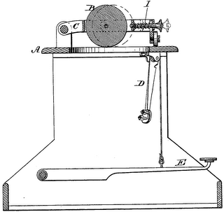

*posted by Koichi Yasuoka at [11:22 AM](http://yasuoka.blogspot.com/2009/05/with-older-manual-typewriters-each.html)* [6 comments](https://www.blogger.com/comment/fullpage/post/31607099/534383590245123700)

## Tuesday, April 28, 2009

> Sholes in 1869 took on as partner a burly, swaggering, salesman character named James Dunsmore. Dunsmore did not have two nickels to rub together, but he had plenty of grit and saw in the typing machine a chance to make a fortune. First, however, he wanted Sholes to improve the crude device, and he imposed on the inventor for a succession of some 50 models---each reflecting some minor improvement---before he had the machine he wanted. At that point, Dunsmore began approaching manufacturers. After an unsuccessful attempt to sell exclusive manufacturing rights to Western Union Company for a reported $50,000, Dunsmore and an associate approached Mr. Philo Remington, president of the Remington Company. -- *James M. Utterback: Mastering the Dynamics of Innovation, Harvard Business School Press, Boston (1996)*.

His name was James Densmore, not Dunsmore. Mr. Densmore in 1869 was successful in oil trading at Pennsylvania, so he had a lot of money at that time. First, Mr. Densmore tried to find customers for Sholes' Type-Writer. In Chicago, he contacted Mr. Edward Payson Porter and then delivered several machines to Porter's Telegraph College [as I mentioned before](http://yasuoka.blogspot.com/2006/09/porters-telegraph-collegeno.html). After the failure at Porter's Telegraph College, Mr. Densmore started to find manufacturers. In New York, he contacted Mr. George Harrington of the American Telegraph Works, but Sholes' Type-Writer was severely criticized by one of Harrington's partners, Mr. Thomas Alva Edison. In St. Louis, Mr. Densmore contacted Mr. Charles Edward Weller to exhibit Sholes' Type-Writer in St. Louis Fair. Again in Chicago, Mr. Densmore contacted Mr. Anson Stager, who was the president of Western Electric Manufacturing, but Western Electric Manufacturing couldn't manufacture the Type-Writer. Then, in Ilion, Mr. Densmore contacted Mr. Philo Remington of E. Remington & Sons (cf. *Koichi Yasuoka and Motoko Yasuoka: Myth of QWERTY Keyboard, NTT Publishing, Tokyo (2008)*).

*posted by Koichi Yasuoka at [3:14 PM](http://yasuoka.blogspot.com/2009/04/sholes-in-1869-took-on-as-partner-burly.html)* [0 comments](https://www.blogger.com/comment/fullpage/post/31607099/8752330524611691351)

## Monday, April 27, 2009

> I also wrote a second program, NADIST, to calculate the distances between all pairs of letters around the rim of a Sholes and Glidden type basket. The original letter arrangement around the basket was:

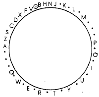

> where * represents a number or a punctuation mark. The lower two rows of the keyboard alternate along the half of the type basket nearest the operator, from left to right, and the upper two keyboard rows alternate in a similar manner around the back rim of the basket. -- *Richard E. Dickerson: "Did Sholes and Densmore Know What They Were Doing When They Designed Their Keyboard?", ETCetera, No.6 (February 1989), pp.6-9*.

I investigated several Sholes & Glidden Type-Writers, and found that their type baskets are all arranged as shown below (top view). In fact, A is placed next to Q, not next to Z. And Z is in between S and C. Why did Dr. Dickerson make such a mistake?

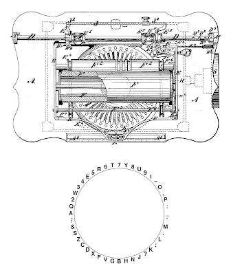

*posted by Koichi Yasuoka at [11:06 AM](http://yasuoka.blogspot.com/2009/04/i-also-wrote-second-program-nadist-to.html)* [0 comments](https://www.blogger.com/comment/fullpage/post/31607099/1637704461906424675)

## Sunday, April 26, 2009

> Frank R. McGurrin, a young law clerk in Grand Rapids, Michigan, in 1878 competed with his employer on the office's Model 1 Remington typewriter. ... By the end of the year he was able to type ninety words per minute---still considered an excellent speed now---from new copy without looking at the keyboard. ... In an 1888 contest in Cincinnati, he confronted Louis Traub, an agent for the Caligraph, possibly the best selling of the two-keyboard machines. McGurrin won decisively, achieving ninety-five words per minute from dictation and ninety-eight from copying against Traub's eighty-three and seventy-one. ... McGurrin continued on the exhibition circuit, promoting Remington as he achieved up to 125 words per minute. For all his prowess, McGurrin had no students and published no books. -- *Edward Tenner: Our Own Devices, Alfred A. Knopf, New York (2003).*

Frank R. McGurrin? Well, R seems wrong for the middle name of [Mr. Frank Edward McGurrin](http://yasuoka.blogspot.com/2006/08/salt-lake-city-utah-dec.html). In fact Mr. McGurrin had several students. In 1890, for example, he taught typewriting in his shorthand college at the Progress Building, Salt Lake City (cf. *"Practical Shorthand College", The Salt Lake Daily Tribune, Vol.38, No.97 (February 4, 1890), p.4, l.7*). And Mr. McGurrin wrote at least one book, titled "Typewriter Speed and How to Acquire It" (J. F. McClain, New York, 1891) with five other leading typists at that time: [Miss Mae E. Orr](http://yasuoka.blogspot.com/2006/12/modern-method-of-touch-typing-in-which.html), Mr. Edward James Manning, Miss Emmeline S. Owen, Mr. Thomas W. Osborne, and Mr. George Alexander McBride. In this book Mr. McGurrin mentioned the way how he operated Remington without looking at the keyboard.

*posted by Koichi Yasuoka at [11:47 AM](http://yasuoka.blogspot.com/2009/04/frank-r.html)* [0 comments](https://www.blogger.com/comment/fullpage/post/31607099/2645860753810858789)

## Wednesday, April 09, 2008

> Margaret Elizabeth Vater Longley (1831-1912), a journalist from Cincinnati, was a member of the executive committee of the National Woman Suffrage Association and would become a vice president of the Ohio association. Through 1870 she took pains to work with both camps of suffragists. Margaret married Elias Longley in 1847, while they both lived in a utopian community in Cincinnati. Her husband was a highly regarded stenographic reporter and advocate of phonetic spelling, who ran a publishing company in Cincinnati from 1847 to 1862. For a time in 1869, Margaret was an editor of the Dayton *Woman's Advocate*. The Longleys moved to California in 1885, and in the 1890s, Margaret headed the Los Angeles Campaign Committee for a referendum of suffrage. -- *Ann D. Gordon: The Selected Papers of Elizabeth Cady Stanton & Susan B. Anthony, Vol.II: Against an Aristocracy of Sex 1866 to 1873, Rutgers University Press, New Brunswick (2000).*

Her name was Elizabeth Margaret Vater Longley, not Margaret Elizabeth Vater Longley. She was born on August 3, 1830, at St. Pancras, London. She married with Elias Longley on May 12, 1847, at Cincinnati, Ohio. In 1869 she was an editor of *Woman's Advocate* and in 1877 she was a court reporter of *Cincinnati Tägliche Abend-Post*. In 1882 she was a teacher of the Cincinnati Shorthand and Type-Writer Institute, and published "[Type-Writer Lessons for the Use of Teachers and Learners Adapted to Remington's Perfected Type-Writers](http://kanji.zinbun.kyoto-u.ac.jp/~yasuoka/QWERTY/1882LongleyMrs-R.djvu)" and "[Caligraph Lessons for the Use of Teachers and Learners Designed to Develop Accurate and Reliable Operators](http://kanji.zinbun.kyoto-u.ac.jp/~yasuoka/QWERTY/1882LongleyMrs-C.djvu)" to spread her eight-finger typing method. She left Cincinnati in May, 1885, and then resided South Pasadena, California. She became the Vice-President of People's Party in California on May 22, 1894. She died on April 17, 1912, at South Pasadena (cf. *Koichi Yasuoka and Motoko Yasuoka: Myth of QWERTY Keyboard, NTT Publishing, Tokyo (2008)*).

*posted by Koichi Yasuoka at [10:12 PM](http://yasuoka.blogspot.com/2008/04/margaret-elizabeth-vater-longley-1831.html)* [0 comments](https://www.blogger.com/comment/fullpage/post/31607099/6648041111732589754)

## Monday, December 03, 2007

> In 1932-33 the Carnegie Foundation for the Advancement of Science assigned two substantial research grants to the University of Washington to determine why typewriting is difficult to learn, slow and fatiguing to perform, and conducive to errors, "in order that humanity may benefit from the findings." By exhaustive tests, motion analyses, letter counts, finger work loads, and functional try-outs, the Carnegie Study of Typewriting proved conclusively that most of the difficulties in typing result from the haphazard keyboard designed for two finger typists in 1873. ... The resulting "Simplified Keyboard" was mathematically, experimentally, and practically tested. -- *August Dvorak: "Horse and Buggy Typewriters?", The Abilene Reporter-News, Vol.75, No.82 (September 25, 1955), Sec.B, p.8, l.3-5.*

Well, Prof. Dvorak, you mentioned here in the article shown above that your Carnegie Study was in 1932-33, but in fact it was in 1933-35. You mentioned here that your Carnegie Study proved that the difficulties in typing result from Sholes' keyboard, but your Carnegie Study should have been "improvement in the teaching of typewriting by use of an improved keyboard" (cf. *The Carnegie Foundation for the Advancement of Teaching, Thirty-first Annual Report (June 30, 1936), pp.76-77*). Furthermore, you mentioned here that your "Simplified Keyboard" was resulted after your Carnegie Study, but in fact you perfected your "Simplified Keyboard" on May 21, 1932 (cf. [U. S. Patent No.2040248](http://patimg1.uspto.gov/.piw?docid=02040248&IDKey=NONE)). It seems queer for me. Prof. Dvorak, are you really August Dvorak?

*posted by Koichi Yasuoka at [5:04 PM](http://yasuoka.blogspot.com/2007/12/in-1932-33-carnegie-foundation-for.html)* [0 comments](https://www.blogger.com/comment/fullpage/post/31607099/3776788648358031558)

## Tuesday, November 20, 2007

> Sholes' machine had a rather sluggish action, too, because the type bars depended on gravity to fall back into place. They clashed and jammed. His first keyboard was laid out alphabetically, but then he moved the letters around to find a pattern which would make the type bars collide least. Finally, he wound up with the letters most frequently joined in words moved as far apart as possible. This is the standard keyboard today. -- *Peter T. White: "Pyfgcrl vs. Qwertyuiop", The New York Times, Vol.CV, No.35792 (January 22, 1956), Magazine Section, pp.18,20.*

As far apart as possible? No. In English the most frequently-used letter sequence is "th". On QWERTY keyboard, you see T and H are adjacently placed. The second is "er" + "re", also placed in neighborhood of one another. Mr. White was too credulous of enthusiasts for Dvorak keyboard.

*posted by Koichi Yasuoka at [10:16 PM](http://yasuoka.blogspot.com/2007/11/sholes-machine-had-rather-sluggish.html)* [0 comments](https://www.blogger.com/comment/fullpage/post/31607099/6776150358743334199)

## Thursday, August 16, 2007

> **Frank McGurrin**, a court stenographer in Salt Lake City, challenged **Louis Taub**, a Cincinnati typing teacher who claimed to be the fastest typist in the world. McGurrin had taught himself a 10-finger method for using his Remington. Taub used a more widely accepted four-finger method to produce typewritten documents on his Caligraph, a machine with one set of keys for upper-case letters and another for lower case. -- *"Early Salt Laker's Typewriter Role is Chronicled", Deseret News, 141st Year, No.200 (December 31, 1990), p.B2, l.1.*

His name was [Louis Traub](http://yasuoka.blogspot.com/2006/08/now-cincinnati-had-another-typewriting.html), not Taub, as your *Deseret News* reported hundred years ago:

> A typewriting contest took place here yesterday, between Frank E. McGurrin, of Salt Lake, and Louis Traub, of Cincinnati. The time occupied was one hour and thirty minutes, in which the report of the judges says McGurrin scored 8700 words and Traub 6938 words, half from dictation and half from manuscript. -- *"Typewriting Contest", The Deseret News, Vol.XXXVII, No.29 (August 1, 1888), p.1, l.4.*

Once you reported his name as "Louis Traub", and why now you report as "Louis Taub"?

*posted by Koichi Yasuoka at [10:41 AM](http://yasuoka.blogspot.com/2007/08/frank-mcgurrin-court-stenographer-in.html)* [0 comments](https://www.blogger.com/comment/fullpage/post/31607099/3143553015633333729)

## Friday, July 06, 2007

> In the late 1800s, there was no standard pattern for the arrangement of letters on the typewriter keyboard. Then in 1873 Christopher Scholes helped design a "new improved" layout. The layout became known as QWERTY, after the letter arrangement of the six letters in the top left row. QWERTY was chosen to *maximize* the distance between the most frequently used letters. This was a good solution in its day, it deliberately slowed down the typist, and reduced the jamming of keys on manual typewriters. By 1904, the Remington Sewing Machine Company of New York was mass-producing typewriters with this layout, and it became the de facto industry standard. -- *Avinash K. Dixit and Barry J. Nalebuff: Thinking Strategically, W. W. Norton, New York (1991)*.

It is proper that there was no standard arrangement for the typewriter keyboard before 1873, since there had been no commercial typewriter before 1873. QWERTY keyboard was designed by Mr. Christopher Latham Sholes, not Scholes, for the first commercial typewriter manufactured by E. Remington & Sons. In fact, Mr. Sholes didn't intend to maximize the distance between the most frequently used letters. In English the most frequently-used letter sequence is "th". You see T and H are near on QWERTY. The second frequently-used letter sequence is "er" + "re", where E and R are next to one another on QWERTY.

Furthermore, the Remington Sewing Machine Company, a subsidiary of E. Remington & Sons, was a manufacturer of the sewing machines, but it never manufactured any typewriters. The Remington Sewing Machine Company was absorbed by the Remington Arms Company in March, 1888, so it never existed in 1904. E. Remington & Sons sold its typewriter division to Wyckoff, Seamans & Benedict in March, 1886, and the rest of E. Remington & Sons was bought by Hartley & Graham in February, 1888, forming the Remington Arms Company.

*posted by Koichi Yasuoka at [4:11 PM](http://yasuoka.blogspot.com/2007/07/in-late-1800s-there-was-no-standard.html)* [3 comments](https://www.blogger.com/comment/fullpage/post/31607099/3085722718085956850)

## Wednesday, May 23, 2007

> On July 25, 1888, the first typing contest was held to determine which, McGurrin or Taub, was the fastest. McGurrin's ten-finger typing won easily over Taub, who used four fingers and looked at the keys when he typed. Women didn't compete in these first speed contests because there were very few female secretaries in those days. But they broke into office work shortly thereafter when the YWCA started teaching typing to women. -- *R. C. Cassingham: The Dvorak Keyboard, Freelance Communications, Arcata (1986).*

His name was Louis Traub, not Taub, and he was an eight-finger typist on Caligraph No.2 [as I mentioned before](http://yasuoka.blogspot.com/2006/08/mrs-l.html). Furthermore, women did compete in these first speed contests. YWCA of the city of New York had already started free classes for typewriting since October, 1881 (cf. *"Free Educational Classes", Eleventh Annual Report of the Young Women's Christian Association of the City of New York (January 1882), pp.11-13*). On August 1, 1888, a speed contest of typewriters, under the auspices of the Metropolitan Stenographers' Association, was competed at New York by two ladies and two gentlemen: Miss M. C. Grant, Miss Mae E. Orr, Mr. Emanuel Myerson, and Mr. Frank Edward McGurrin (cf. *"The Metropolitan Typewriter Contest", The Phonographic World, Vol.3, No.12 (August 1888), p.263*). On August 13, 1888, five ladies and five gentlemen competed a typewriter tournament, which was held at Toronto as a part of Seventh Annual Convention of the Canadian Shorthand Society. In the tournament Miss Mae E. Orr, a two-finger typist on Remington No.2, won the gold medal against Mr. Frank Edward McGurrin (cf. *"Canadian Shorthand Society", The Cosmopolitan Shorthander, Vol.9, No.8 (September 1888), pp.210-215*).

*posted by Koichi Yasuoka at [2:33 PM](http://yasuoka.blogspot.com/2007/05/on-july-25-1888-first-typing-contest.html)* [0 comments](https://www.blogger.com/comment/fullpage/post/31607099/7876621260929626351)

## Thursday, April 26, 2007

> Densmore bought the *Walworth County Independent* in 1855, changed its name to Elkhorn *Independent*, and published it until 1857. Then he sold it and gave up journalism as a career. Later he summed up his eight years of newspaper experience in Wisconsin by saying: "I started at Oshkosh, succeeded eminently, and threw it all away. I started again at Kenosha and Elkhorn, succeeded beyond my hopes, got more and threw it all away." He departed from Wisconsin without fortune he had come to get but he had added to the vigor and picturesqueness of early journalism in the State. -- *Richard N. Current: "The First Newspaperman in Oshkosh", Wisconsin Magazine of History, Vol.30, No.4 (June 1947), pp.408-422.*

No, Mr. James Densmore neither departed from Wisconsin in 1857, nor gave up journalism then. In 1860 he still stayed in Hudson, Wisconsin. He edited Hudson Chronicle there, writing down his political positions on it (cf. *James Densmore: "The Bond Question", Hudson Chronicle, Vol.4, No.16 (March 31, 1860), p.2, l.2*). In fact, Mr. Densmore in 1860 resided at St. Paul, Minnesota, 10 miles west from Hudson, but he could not depart from Wisconsin journalism.

*posted by Koichi Yasuoka at [11:14 AM](http://yasuoka.blogspot.com/2007/04/densmore-bought-walworth-county.html)* [0 comments](https://www.blogger.com/comment/fullpage/post/31607099/7072105456001894221)

## Wednesday, April 25, 2007

> Sholes and Densmore were not strangers even at the time they worked together on the Kenosha *Telegraph*, which was fifteen years before they came into business relations in the typewriter. They had met eight or ten years before that at Madison, Wisconsin. -- *Henry W. Roby's Story of the Invention of the Typewriter, George Banta Publishing, Menasha (1925).*

It is incredible for me that Messrs. Christopher Latham Sholes and James Densmore had met that time at Madison. It is sure that in December, 1853, Mr. Densmore became associated with Mr. Sholes on the Kenosha Telegraph (cf. *C. L. Sholes: "James Densmore", Kenosha Telegraph, Vol.14, No.28 (December 30, 1853), p.2, l.1*). Then, according to Dr. Roby, Messrs. Sholes and Densmore had met at Madison in 1843 or 1845. It's impossible. Mr. Densmore landed to Wisconsin, at Milwaukee, in 1848 (cf. *James Densmore: "A Little Personal Gossip", Oshkosh Democrat, Vol.3, No.1 (March 7, 1851), p.2, l.3-4*), and before that he had resided in Pennsylvania for about fourteen years (cf. *Family Record of James Compton and Clarissa Cleveland-Compton, Porter Cleveland-Compton (1901)*). I've found that Messrs. Sholes and Densmore had met at Madison on January 13, 1853 (cf. *"Editor's Convention", Oshkosh Democrat, Vol.4, No.48 (January 28, 1853), p.1, l.3-5*), but I'm not sure that it was their first time.

*posted by Koichi Yasuoka at [9:49 AM](http://yasuoka.blogspot.com/2007/04/sholes-and-densmore-were-not-strangers.html)* [0 comments](https://www.blogger.com/comment/fullpage/post/31607099/5516221453300838954)

## Monday, April 16, 2007

> A certain Mrs. L. B. Longley, the owner of a Shorthand and Typing Institute, had the audacity to the state that all typists should use all the fingers of both hands. The *Cosmopolitan Shorthander* in 1877 condemned Mrs. Longley and stated that unless the third finger of the hand had been previously trained to touch the keys of a piano, it was not worth while attempting to use this finger in operating the typewriter. It went on to say that the best operators all used only the first two fingers of each hand and doubted whether a higher speed could be obtained by the use of three. Such an important publications could have put Mrs. Longley in her place had it not been for Mr. Frank E. McGurrin of Salt Lake City who, quite accidentally, rescued Mrs. Longley and established the four-bank keyboard once and for all. -- *Wilfred A. Beeching: Century of the Typewriter, Heinemann, London (1974).*

Mrs. L. B. Longley? Is it a misspelling for Mrs. Elizabeth Margaret Vater Longley? If so, Mr. Frank Edward McGurrin never rescued Mrs. Longley, but he beated one of her pupils, Mr. Louis Traub, on July 25, 1888, [as I mentioned before](http://yasuoka.blogspot.com/2006/08/mrs-l.html). Furthermore, *The Cosmopolitan Shorthander* was never published in 1877. The first issue of the magazine was published in May, 1880, under the title of *The Canadian Illustrated Shorthand Writer*. The title was changed into *Bengough's Cosmopolitan Shorthand Writer* in September, 1881, then *The Cosmopolitan Shorthand Writer* in January, 1884, and finally *The Cosmopolitan Shorthander* in June, 1884.

*posted by Koichi Yasuoka at [4:05 PM](http://yasuoka.blogspot.com/2007/04/certain-mrs.html)* [0 comments](https://www.blogger.com/comment/fullpage/post/31607099/8564839253720001855)

## Thursday, March 01, 2007

> Charles Clark Sholes invented the typewriter, which was the size of a sewing machine, in 1866. He patented it two years later and introduced it to the public through E. Remington and Sons. Its lettered keys are arranged in four rows, and each type-carrier is launched as its key is struck. -- *"The Typewriter Timeline", The Inteligencer (Doylestown, Pennsylvania), February 22, 2004, p.D7*.

Mr. Charles Clark Sholes, who was a brother of Mr. Christopher Latham Sholes, died at Kenosha, Wisconsin, on October 5, 1867, [as I mentioned before](http://yasuoka.blogspot.com/2006/11/it-seems-obvious-that-traditional.html). Mr. Charles Clark Sholes could never introduce his typewriter to E. Remington and Sons in 1868, since he never invented the typewriter.

*posted by Koichi Yasuoka at [11:09 AM](http://yasuoka.blogspot.com/2007/03/charles-clark-sholes-invented.html)* [0 comments](https://www.blogger.com/comment/fullpage/post/31607099/117271582886585602)

## Friday, December 08, 2006

> The modern method of touch typing, in which the typist employs all fingers and refrains from looking at the keyboard, was first developed by Frank E. McGurrin of Salt Lake City. Touch typing was slow to gain acceptance, even though McGurrin demonstrated superior performance in a well-publicized typewriting contest in 1888 while competing against a highly proficient typist who employed only four fingers and looked at the keyboard. -- *William E. Cooper: Cognitive Aspects of Skilled Typewriting, Springer-Verlag, New York (1983).*

McGurrin demonstrated superior performance? Yes, but in 1888 some other people demonstrated more superior performance without touch typing. For example, in the typewriter contest at Toronto on August 13, 1888, Mr. Frank Edward McGurrin was beaten by Miss Mae E. Orr, who was a two-finger typist (cf. *"Canadian Shorthand Society", The Cosmopolitan Shorthander, Vol.9, No.8 (September 1888), pp.210-215*). Miss Orr was employed by Remington later and became a director in 1907 (cf. *Claudia Q. Murphy: "Little Life Stories - Miss Mary E. Orr, the First Woman to Become a Director in a Big Corporation", Success Magazine, Vol.10, No.163 (December 1907), p.831*). On the other hand, Mr. McGurrin retired from his career as a typist before Utah became a state, and he started his new career as a banker (cf. *"Rites Held for Club Founder", Oakland Tribune, Vol.119, No.50 (August 19, 1933), p.3, l.7*). Mr. Frank Edward McGurrin was surely one of the earliest touch typists, but it is questionable that he could keep superior performance than two-finger typists at that time.

*posted by Koichi Yasuoka at [4:42 PM](http://yasuoka.blogspot.com/2006/12/modern-method-of-touch-typing-in-which.html)* [0 comments](https://www.blogger.com/comment/fullpage/post/31607099/116556444370965936)

## Tuesday, November 21, 2006

> It seems obvious that the traditional typewriter keyboard---the "qwerty" or "Sholes" keyboard---presents many difficulties for novice typists. The arrangement of the letters on the keyboard seems arbitrary and difficult to learn. The keys were organized by the Sholes brothers in 1873 to minimize the jamming of type bars in their early design of the typewriter. They placed the keys that were typed successively as far apart on the keyboard as possible, so that the type bars would approach each other at a relatively sharp angle, thus minimizing the chance of jamming. -- *Donald A. Norman and Diane Fisher: "Why Alphabetic Keyboards Are Not Easy to Use: Keyboard Layout Doesn't Much Matter", Human Factors, Vol.24, No.5 (October 1982), pp.509-519.*

The Sholes brothers? Mr. Christopher Latham Sholes and whom? Mr. Henry O. Sholes was at Lawrence, Kansas, in 1873 when Mr. Christopher Latham Sholes invented QWERTY keyboard at Milwaukee, Wisconsin. Mr. Charles Clark Sholes was at Kenosha, Wisconsin, but he died there on October 5, 1867 (cf. *"Died", The Kenosha Telegraph, Vol.28, No.19 (October 10, 1867), p.2, l.1-2*). No brother could help Mr. Christopher Latham Sholes when he organized QWERTY keyboard. Furthermore, most-commonly-typed letter sequence in English is "th", which is placed adjacently on the QWERTY keyboard. The second is "er" + "re", also placed in the neighborhood of one another. They never stay far apart on the QWERTY keyboard.

*posted by Koichi Yasuoka at [3:43 PM](http://yasuoka.blogspot.com/2006/11/it-seems-obvious-that-traditional.html)* [5 comments](https://www.blogger.com/comment/fullpage/post/31607099/116409293179251077)

## Sunday, October 29, 2006

> An engineer named Christopher Scholes designed the QWERTY layout in 1873 specifically to slow typists down; the typewriting machines of the day tended to jam if the typist went too fast. But then the Remington Sewing Machine Company mass-produced a typewriter using the QWERTY keyboard, which meant that lots of typists began to learn the system, which meant that other typewriter companies began to offer the QWERTY keyboard, which meant that still more typists began to learn it, et cetera, et cetera. -- *M. Mitchell Waldrop: Complexity, Simon & Schuster, New York (1992).*

The QWERTY keyboard was invented by Mr. Christopher Latham Sholes, not Scholes (cf. [U. S. Patent No.207559](http://patimg2.uspto.gov/.piw?docid=00207559&IDKey=NONE)). In 1873 Mr. Sholes was in the position of editor-in-chief of The Daily Milwaukee News, not an engineer (cf. *"Personal Mention", Milwaukee Daily Sentinel, Vol.30, No.293 (December 11, 1873), p.8, l.3*). "To slow typists down" is nothing but a hoax by Mr. Robert Parkinson, [as I mentioned before](http://yasuoka.blogspot.com/2006/08/before-going-on-with-history-of-dr.html). It was E. Remington & Sons, not Remington Sewing Machine Company, that manufactured [Sholes & Glidden Type Writer](http://www.typewritermuseum.org/collection/brands/index.php3?machine=sholesglid1&cat=ku) in September, 1873 (cf. *John A. Zellers: The Typewriter - A Short History on Its 75th Anniversary 1873-1948, Newcomen Society of England American Branch, New York (1948)*). The other typewriter companies, including [Caligraph](http://www.typewritermuseum.org/collection/brands/index.php3?machine=caligr&cat=ku) and [Hammond](http://www.typewritermuseum.org/collection/brands/index.php3?machine=hammond1&cat=ks), offered their own keyboard arrangements, not QWERTY, in the 1880's. Mr. Waldrop should study more on the history of typewriter before he argue with "increasing returns".

*posted by Koichi Yasuoka at [10:09 PM](http://yasuoka.blogspot.com/2006/10/engineer-named-christopher-scholes.html)* [2 comments](https://www.blogger.com/comment/fullpage/post/31607099/116213013245499630)

## Tuesday, October 24, 2006

> It took considerably longer for someone to realize the fundamental weakness of the Qwerty keyboard. That someone was August Dvorak, director of research at the University of Washington. With the help of two grants from the Carnegie Corporation, Dvorak analyzed the problems of teaching and learning typing. -- *Shirley Boes Neill: "Dvorak vs. Qwerty: Will Tradition Win Again?", Phi Delta Kappan, Vol.61, No.10 (June 1980), pp.671-673.*

[Dr. August Dvorak](http://patimg1.uspto.gov/.piw?docid=US002040248&IDKey=NONE) was not the first one who attempted to oust the QWERTY keyboard. [Mr. George Canfield Blickensderfer](http://patimg2.uspto.gov/.piw?docid=US000459093&IDKey=NONE), [Mr. Sidney Walter Rowell](http://patimg2.uspto.gov/.piw?docid=US000943466&IDKey=NONE), [Mr. Framerz Mehervanji Muncherji Manaji](http://v3.espacenet.com/origdoc?RPN=GB116538&QPN=GB116538), [Mr. Chandler Wolcott](http://patimg1.uspto.gov/.piw?docid=US001342244&IDKey=NONE), [Mr. William Wilson Nelson](http://v3.espacenet.com/origdoc?RPN=GB155446&QPN=GB155446), [Dr. Roy Edward Hoke](http://patimg1.uspto.gov/.piw?docid=US001506426&IDKey=NONE), [Mr. William Allen Gilbert](http://patents1.ic.gc.ca/details?patent_number=283983), and so many people before Dr. Dvorak challenged to the tyranny of QWERTY. [Mr. Christopher Latham Sholes](http://yasuoka.blogspot.com/2006/08/printing-telegraphic-dispatches.html), the inventor of the QWERTY keyboard, was also unsatisfied with QWERTY, and tried to improve the keyboard arrangement in 1880's. On his improved keyboard Mr. Sholes placed the vowels in "home row" of the right hand, and frequently-used consonants, T, N, S, H, R, and D, in its above row (shown below, taken from [U. S. Patent No.568630](http://patimg1.uspto.gov/.piw?docid=US000568630&IDKey=NONE)). After Mr. Sholes died, however, his patents were assigned to Mr. Clarence Walker Seamans, the first president of the Union Typewriter Company. Mr. Seamans, who pushed forward the oligopoly of QWERTY, never released Mr. Sholes' improved keyboard to the market.

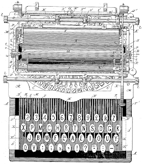

*posted by Koichi Yasuoka at [4:27 PM](http://yasuoka.blogspot.com/2006/10/it-took-considerably-longer-for.html)* [0 comments](https://www.blogger.com/comment/fullpage/post/31607099/116168003975673358)

## Thursday, October 19, 2006

> The first practical typewriter was invented by Latham Sholes in 1867. Sholes had for partners S. W. Soule and Carlos Glidden, but these two men became discouraged and dropped out. It wasn't till some years later that Sholes got his machine ready for the market. Then he took it to a big firm of gunmakers, the Remingtons, and it at once began to sell on a large scale. Sholes remained in the employ of the Remingtons up to the time of his death. -- *"History of the Typewriter", The Elyria Chronicle Daily (Elyria, Ohio), Vol.3, No.660 (August 18, 1906), p.8, l.2.*

Mr. Carlos Glidden didn't drop out of inventing "Type Writer". He kept in touch with Mr. Christopher Latham Sholes, and he kept improving "Type Writer" (cf. [U. S. Patent No.200351](http://patimg2.uspto.gov/.piw?docid=US000200351&IDKey=NONE)). However, Mr. Glidden was ill and deceased on March 11, 1877. It was Mr. James Densmore, the attorney of Mr. Sholes, and Mr. George Washington Newton Yost that took "Type Writer" to E. Remington & Sons in February, 1873 (cf. *The Story of the Typewriter 1873-1923, Herkimer County Historical Society, Herkimer (1923)*). Then Messrs. Densmore and Yost founded The Type Writer Company to secure the patents of Mr. Sholes, so that Mr. Sholes didn't directly contact with Remington people (cf. [U. S. Patent No.182511](http://patimg1.uspto.gov/.piw?docid=US000182511&IDKey=NONE)). Mr. Sholes had never been in the employ of Remington until his death on February 17, 1890 (cf. *"Mr. Sholes Dead", The Milwaukee Sentinel, No.15692 (February 18, 1890), p.1, l.7*). After his death, some of his patents were assigned to Wyckoff, Seamans & Benedict, the parent company of Remington Standard Type-Writer Manufacturing Company (cf. [U. S. Patent No.568630](http://patimg1.uspto.gov/.piw?docid=US000568630&IDKey=NONE)).

*posted by Koichi Yasuoka at [8:36 PM](http://yasuoka.blogspot.com/2006/10/first-practical-typewriter-was.html)* [0 comments](https://www.blogger.com/comment/fullpage/post/31607099/116126411104772110)

## Wednesday, October 04, 2006

> The first typewriters could print only upper case letters. The addition of lower case letters was, at first, accomplished by adding a new key for each lower case letter, so in effect there were two separate keyboards. Some early typewriters organized the keys for upper case differently than for lower case. Imagine how difficult it would be to learn that keyboard! It took years to develop the shift key so that both upper and lower case letters could share the same key. This was a nontrivial invention, combining mechanical ingenuity with a dual-faced typebar. -- *Donald A. Norman: The Psychology of Everyday Things, Basic Books, New York (1988).*

Wrong. The first typewriter with upper and lower case letters was [Remington No.2](http://www.typewritermuseum.org/collection/brands/index.php3?machine=rem2&cat=ku) that was introduced in January, 1878 (cf. *"The Improved Type-Writer", The Type-Writer Magazine, Vol.2, No.1 (January 1878), pp.10-11,17,19-24*). Remington No.2 actualized platen-shift mechanism by Mr. Byron Alden Brooks, which literally shifts the platen to the front in order to type upper case letters, so that both upper and lower case letters shared the same typebar and the same key (shown below, taken from [U. S. Patent No.202923](http://patimg1.uspto.gov/.piw?docid=00202923&IDKey=NONE)). The first typewriter with separate keys for upper and lower case letters was [Caligraph No.2](http://www.typewritermuseum.org/collection/brands/index.php3?machine=caligraph2&cat=ku) that was released four years behind Remington No.2 (cf. *"The Caligraph", The Caligraph Quarterly, Vol.1, No.1 (October 1882), pp.1-2,20-21,30*). Prof. Norman's "psychology" doesn't stick to the facts on typewriters.

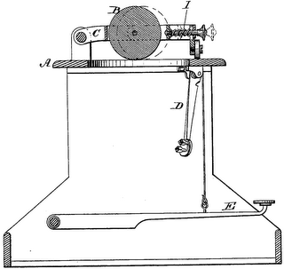

*posted by Koichi Yasuoka at [2:23 PM](http://yasuoka.blogspot.com/2006/10/first-typewriters-could-print-only.html)* [0 comments](https://www.blogger.com/comment/fullpage/post/31607099/115994016306161546)

## Friday, September 29, 2006

> Porter's Telegraph College  
> No. 126 Washington Street,  
> (Court House Square)  
> **CHICAGO, ILL.**

> The most complete Telegraph School in the country, having Five Departments. Each Department complete in itself, viz: Primary, Penmanship, Type Writing, Air-Line Telegraph, Lectures.  
> The Chicago City Telegraph Line in connection with this Institution is *Forty Miles* in extent, and supports *Fifty Offices* wherein students may earn their board after two months' practice, and before graduating may earn back their entire Tuition.

> **THE AMERICAN TYPE WRITER.**

> By touching keys like a Piano this machine produces letters faster than the most rapid penman. Its use in this College enables Students to become expert Telegraphers without regard to their penmanship.  
> Competing Telegraph Lines are increasing the demand for Operators. Young Men and Ladies should consider the advantages of a Telegraphic Education.  
> For Type Writer and College Circulars, address

> **E. PAYSON PORTER,**  
> Principal Porter's Tel. Col., Chicago, Ill.

> -- *Saint Joseph Herald, Vol.3, No.29 (November 21, 1868), p.3, l.7.*

In 1868, Mr. Christopher Latham Sholes' Type Writer was adopted by Porter's Telegraph College, Chicago. It was his second model and, being different from [his first model](http://yasuoka.blogspot.com/2006/09/qwerty-was-devised-by-christopher.html), it had a piano-like two-row keyboard (shown below, taken from [U. S. Patent No.79265](http://patimg2.uspto.gov/.piw?docid=00079265&IDKey=NONE)). It had twenty-eight keys, thus it could print capital letters (A to Z), comma and period, but not numerals (cf. *"Writing by Machinery", Milwaukee Daily Sentinel, Vol.26, No.236 (October 6, 1869), p.1, l.4*). Furthermore, its printing result was too thin to read. Therefore, Mr. Sholes began to improve his Type Writer, first in its platen (cf. [U. S. Patent No.118491](http://patimg2.uspto.gov/.piw?docid=00118491&IDKey=NONE)), then in its keyboard (cf. [U. S. Patent No.182511](http://patimg1.uspto.gov/.piw?docid=00182511&IDKey=NONE)).

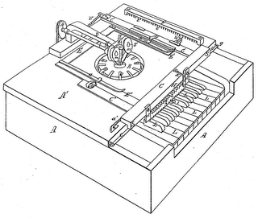

*posted by Koichi Yasuoka at [10:21 PM](http://yasuoka.blogspot.com/2006/09/porters-telegraph-collegeno.html)* [0 comments](https://www.blogger.com/comment/fullpage/post/31607099/115953735492120692)

## Monday, September 18, 2006

> QWERTY was devised by Christopher Sholes, who began his typewriter-building experiments in 1867. Sholes's first keyboard used piano keys in a single row, with the letters in alphabetical order. But he was soon forced to change that arrangement, because his type bars responded sluggishly. When he struck one key soon after another, the second key's type bar jammed the first bar before the first could fall back, and the first letter was printed again. Key jamming was still an occasional problem some 80 years later, when I had chicken pox, but at least by then the type bars struck the paper from the front side, so you could immediately see what was happening and separate the keys with your fingers. Alas, with Sholes's machine and most other typewriters until the early part of the century, the type bars struck the invisible rear side of the paper, and you didn't know the bars had jammed until you pulled out the page and saw that you had typed 26 lines of uninterrupted E's instead of the Gettysburg Address. -- *Jared Diamond: "The Curse of QWERTY", Discover, Vol.18, No.4 (April 1997), pp.34-42.*

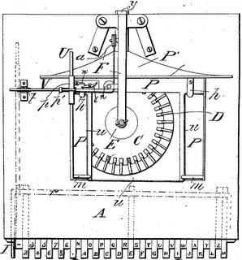

Mr. Christopher Latham Sholes' first type-writing machine, whose patent was filed on October 11, 1867, had a two-row keyboard, neither single-row nor piano-like (shown right, taken from [U. S. Patent No.79868](http://patimg2.uspto.gov/.piw?docid=00079868&IDKey=NONE)). Mr. Sholes adopted a piano-like keyboard in [his second model](http://yasuoka.blogspot.com/2006/09/porters-telegraph-collegeno.html) that was patented on June 23, 1868 (cf. [U. S. Patent No.79265](http://patimg2.uspto.gov/.piw?docid=00079265&IDKey=NONE)). His second model had a two-row keyboard with twenty-eight keys (A to Z, comma and period), which resembled the Hughes-Phelps printing telegraph, [as I mentioned before](http://yasuoka.blogspot.com/2006/08/printing-telegraphic-dispatches.html). Prof. Jared Diamond didn't investigate the early type-writing machines by Mr. Sholes, but did write an imaginative story about them.

*posted by Koichi Yasuoka at [11:28 PM](http://yasuoka.blogspot.com/2006/09/qwerty-was-devised-by-christopher.html)* [0 comments](https://www.blogger.com/comment/fullpage/post/31607099/115859267538751531)

## Friday, September 08, 2006

> In their innocence Sholes and his partners first arranged the letters of the typewriter's keyboard in alphabetical order, but the uselessness of this system soon became apparent. ... You didn't have to type very fast for the letters to rise up and jam at the platen (the roller of a typewriter), the very place where they were supposed to print. To end that annoyance, James Densmore asked his son-in-law, a Pennsylvania school superintendent (who surely should have known), what letters and combinations of letters appeared most often in the English language. Then, in 1872, Densmore and Sholes put what they believed to be the most used characters, as far apart as possible in the type basket and ended up with the horror of qwerty. -- *Charles Lekberg: "The Tyranny of Qwerty", Saturday Review of Science, Vol.55, No.40 (September 30, 1972), pp.37-40.*

*posted by Koichi Yasuoka at [11:43 PM](http://yasuoka.blogspot.com/2006/09/in-their-innocence-sholes-and-his.html)* [0 comments](https://www.blogger.com/comment/fullpage/post/31607099/115772741476874999)

## Friday, September 01, 2006

> To improve the usefulness of typewriters, the Smith Premier Typewriter Company introduced the Smith Premier, which used a full keyboard with separate keys for upper and lower case letters. Remington, on the other hand, came up with innovative Remington Model 2, which used the shift key to type both upper and lower case letters using a single character set on the keyboard and dual-faced type bars. This keyboard was better ergonomically designed to reduce the mechanical movement of the hand. Even though the demand for typewriters was virtually nonexistent at the time, the few typewriter manufacturers firmly believed in the great potential of the product. -- *Sridhar Condoor: "Importance of Teaching the History of Technology", Proceedings Frontiers in Education 34th Annual Conference, Vol.1 (October 21, 2004), Session T2G, pp.7-10.*

It was 1889 when the Smith Premier Typewriter Company introduced the first [Smith Premier](http://www.typewritermuseum.org/collection/brands/index.php3?machine=smithpr1&cat=ku) (cf. *"Improvement the Order of the Age", The Century Magazine, Vol.37, No.6 (April 1889), Advertising Supplement, p.75*). And it was more than ten years behind [Remington No.2](http://www.typewritermuseum.org/collection/brands/index.php3?machine=rem2&cat=ku) (cf. *"The Improved Type-Writer", The Type-Writer Magazine, Vol.2, No.1 (January 1878), pp.10-11,17,19-24*). In the 1880's, even before the Smith Premier was introduced, the demand for typewriters were already existent and increased more and more (cf. *"The Future of Writing Machines", The Cosmopolitan Shorthander, Vol.7, No.1 (January 1886), pp.4-6*). Furthermore, Smith Premier was not the first typewriter with a full keyboard. The first one was [Caligraph No.2](http://www.typewritermuseum.org/collection/brands/index.php3?machine=caligraph2&cat=ku), which was introduced by the American Writing Machine Company in 1882 (cf. *"The Caligraph", The Caligraph Quarterly, Vol.1, No.1 (October 1882), pp.1-2,20-21,30*). If Dr. Sridhar Condoor really emphasizes the importance of teaching the history of technology, at least he should clarify the sources of "the history" in his paper. Or he would make such a nonsense to compare the debuts of Smith Premier and Remington No.2.

*posted by Koichi Yasuoka at [11:46 PM](http://yasuoka.blogspot.com/2006/09/to-improve-usefulness-of-typewriters.html)* [2 comments](https://www.blogger.com/comment/fullpage/post/31607099/115712791378564009)

## Tuesday, August 29, 2006

> Back in the 1870's, Sholes & Co., a leading manufacturer of typewriters at the time, received many complaints from users about typewriter keys sticking together if the operator went too fast. In response, management asked its engineers to figure out a way to prevent this from happening. The engineers discussed the problem for a bit and then one of them said, "What if we slowed the operator down? If we did that, the keys wouldn't jam together nearly as much." The result was to have an inefficient keyboard configuration. For example, the letters "O" and "I" are the third and sixth most frequently used letters in the English language, and yet the engineers positioned them on the keyboard so that the relatively weaker fingers had to depress them. This "inefficient logic" pervaded the keyboard, and this brilliant idea solved the problem of keyboard jam-up. -- *Roger von Oech: A Whack on the Side of the Head, Creative Think, Menlo Park (1983).*

It was E. Remington & Sons, not Sholes & Co., that manufactured the first commercial typewriter, [Sholes & Glidden Type-Writer](http://www.typewritermuseum.org/collection/brands/index.php3?machine=sholesglid1&cat=ku), in September, 1873 (cf. *John A. Zellers: The Typewriter - A Short History on Its 75th Anniversary 1873-1948, Newcomen Society of England American Branch, New York (1948)*).

*posted by Koichi Yasuoka at [9:36 PM](http://yasuoka.blogspot.com/2006/08/back-in-1870s-sholes-sons-including.html)* [0 comments](https://www.blogger.com/comment/fullpage/post/31607099/115685663211823185)

## Friday, August 25, 2006

> Before going on with the history of Dr. Dvorak's struggle to have his invention accepted, we should look at how the typewriter keyboard most in use today came about. It turns out that this keyboard was designed experimentally by Christopher Sholes, the inventor of the typewriter, to SLOW THE TYPIST DOWN. The keys on the early machines hung down in sort of a basket arrangement, and pivoted up to strike the platen (roller) from underneath. ... Since the keys had no springs on them, they fell back into place by gravity. This meant their action was very sluggish, and if two keys that were close together in one quadrant of this "basket" were struck rapidly, one after another, they would jam. To overcome this problem, Sholes moved the keys around experimentally until the machine seemed to operate with a minimum of jamming. What he actually did was to make many commonly-used letter sequences awkward and slow to execute. Thus, by "anti-engineering" his typewriter from a human factors point of view, he was able to slow it down so it would function to his satisfaction. -- *Robert Parkinson: "The Dvorak Simplified Keyboard: Forty Years of Frustration", Computers and Automation, Vol.21, No.11 (November 1972), pp.18-25.*

Hoax. Or else, Mr. Parkinson was too credulous of [Dr. August Dvorak's hypothesis](http://yasuoka.blogspot.com/2006/07/in-1873-christopher-latham-sholes.html). In English the most frequently-used letter sequence is "th". On QWERTY keyboard, you see T and H are very easy to strike rapidly. They are neither awkward nor slow to execute. The second frequently-used letter sequence is "er" + "re", which is not awkward, either.

[As I mentioned before](http://yasuoka.blogspot.com/2006/08/printing-telegraphic-dispatches.html), Mr. Christopher Latham Sholes started his keyboard from alphabetical arrangement,

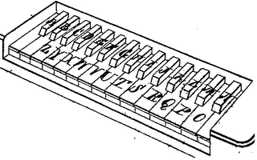

and then imitated piano-like keyboard of the Hughes-Phelps printing telegraph (shown right, taken from [U. S. Patent No.26003](http://patimg1.uspto.gov/.piw?docid=00026003&IDKey=NONE)) in 1867. He changed the keys into button-like ones in April, 1870. In his new model he moved vowels to the upper row of the keyboard in order to put the twenty-six letters in ten columns (shown below, taken from *Koichi Yasuoka: "QWERTY Revisited", Journal of Information Processing and Management, Vol.48, No.2 (May 2005), pp.115-118*). It's the origin of QWERTY.

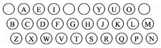

*posted by Koichi Yasuoka at [5:38 PM](http://yasuoka.blogspot.com/2006/08/before-going-on-with-history-of-dr.html)* [0 comments](https://www.blogger.com/comment/fullpage/post/31607099/115649731483752553)

## Tuesday, August 22, 2006

> Mrs L. V. Longley's *Typewriter Lessons* were not sufficient to carry the day immediately for the proponents of eight-finger typing. She was denounced repeatedly in the pages of *Cosmopolitan Shorthander* and eventually was challenged to prove her case by another teacher of typewriting from her own city. The challenger, one Louis Taub, proclaimed the superiority of four-finger typing on the Caligraph. This was a rival machine which had been brought out in 1881 by Densmore's former partner, Yost. It came equipped with a six-row keyboard, accommodating upper- and lower-case keys to make up for its lack of the Remington's shift-action. In 1888, when the first public speed-typing competition was organized which put to the test these contending systems, the honor of Mrs Longley and the Remington was vindicated by a Federal Court stenographer from Salt Lake City who had taught himself to type on a Remington No. 1, way back in 1878. Frank E. McGurrin, the man who entered the lists as their champion against Louis Taub, already had won fame in demonstrations before gasping audiences throughout the West, because, in addition to deploying the `all-finger' technique, he had memorized the QWERTY keyboard. -- *Paul A. David: "Understanding the Economics of QWERTY: the Necessity of History", Economic History and the Modern Economist (William N. Parker ed., Basil Blackwell, Oxford, 1986), pp.30-49.*

Scrutinizing the Cosmopolitan Shorthander, from June/1884 to February/1889 issues, I could find only one article that denounced eight-finger typing (cf. *"Typewriting Instruction", The Cosmopolitan Shorthander, Vol.8, No.5 (May 1887), p.113*) but no other. Denounced repeatedly? No. Several articles recommended use of the ring finger and sometimes the little finger. If Prof. David really read the Cosmopolitan Shorthander, he would never mistake the competitor's name, [Mr. Louis Traub](http://yasuoka.blogspot.com/2006/08/now-cincinnati-had-another-typewriting.html), for Taub, and would never argue that [Mr. Frank Edward McGurrin](http://yasuoka.blogspot.com/2006/08/frank-e.html) vindicated [Mrs. Elizabeth Margaret Vater Longley](http://yasuoka.blogspot.com/2006/08/in-1882-shorthand-and-typewriter.html).

In 1888 Mr. Louis Traub was a principal of Longley's Shorthand and Typewriting Institute, Cincinnati (cf. *"The Challenge Accepted", The Cosmopolitan Shorthander, Vol.9, No.6 (June 1888), p.155*). He had been an eight-finger typist on Caligraph No.2 since Mrs. Longley moved to Los Angeles in May, 1885 (cf. *"Elias Longley's Farewell", The Cosmopolitan Shorthander, Vol.6, No.11 (November 1885), p.200*). Mr. Traub did not challenge Mrs. Longley, but he vindicated her eight-finger method. Mr. Frank Edward McGurrin was an official stenographer of the Third District Court in Salt Lake City, not of the Federal Court there (cf. *"The Question Settled", The Cosmopolitan Shorthander, Vol.9, No.8 (September 1888), pp.226-227*). He was an all-finger typist on Remington No.2 and could operate it blindfolded (cf. *"The Metropolitan Stenographers' Association Typewriter Contest", The Cosmopolitan Shorthander, Vol.9, No.8 (September 1888), pp.217-218*). Mr. McGurrin did not vindicate Mrs. Longley, but he was challenged by one of her pupils. On July 25, 1888, Mr. McGurrin won the typewriter competition in Cincinnati against Mr. Traub. After the competition, Mr. Traub threw his Caligraph away, and started to practice with Remington (cf. *"McGurrin vs. Traub", The Cosmopolitan Shorthander, Vol.10, No.2 (February 1889), pp.21-23*).

*posted by Koichi Yasuoka at [2:44 PM](http://yasuoka.blogspot.com/2006/08/mrs-l.html)* [0 comments](https://www.blogger.com/comment/fullpage/post/31607099/115622722387242388)

## Wednesday, August 16, 2006

> QWERTY, adopted initially by some, but not all, manufacturers, was given a leg up in 1888 when the Shorthand and Typewriter Institute of Cincinnati sponsored a contest between Remington's QWERTY keyboard and a layout used by the American Writing Machine Company's Caligraph model. If typewriter historians are to be believed, the media were altered. "The world press was attracted," Wilfred A. Beeching writes in his *Century of the Typewriter*. Representing Remington was Frank E. McGurrin; in the Caligraph corner, using a double keyboard, the gallant Louis Taub. But, alas, like so many typewriting showdowns, this one didn't live up to its billing. Not only could McGurrin touch-type blindfolded using all ten fingers; poor Taub was proficient only with four. For an unscientific way of determining a keyboard's efficiency, this one is hard to beat. Nevertheless, when the Toronto Typewriters' Congress of 1888 advocated the standardization of the keyboard, nearly all manufacturers switched over to QWERTY. -- *Arthur Krystal: "Against Type?", Harper's Magazine, Vol.305, No.1831 (December 2002), pp.82-88.*

His name was Louis Traub, not Taub, and he was [an eight-finger typist](http://yasuoka.blogspot.com/2006/08/now-cincinnati-had-another-typewriting.html) on Caligraph No.2. Furthermore, the "Toronto Typewriters' Congress" held on August 13, 1888, in the Convocation Hall of the Education Department, Toronto, never advocated the standardization of the keyboard. It was a typewriting tournament held as a part of Seventh Annual Convention of the Canadian Shorthand Society. In the tournament Miss Mae E. Orr, a two-finger typist on Remington No.2, won the gold medal against Mr. Frank Edward McGurrin (cf. *"Canadian Shorthand Society", The Cosmopolitan Shorthander, Vol.9, No.8 (September 1888), pp.210-215*).

The American Writing Machine Company, the manufacturer of Caligraph, changed its keyboard arrangements into QWERTY when releasing the New Century Caligraph in 1898 (cf. *"The New Century Caligraph", Scientific American, Vol.79, No.24 (December 10, 1898), p.372*). It is not due to the "Toronto Typewriters' Congress" but to the Typewriter Trust. On March 30, 1893, the Union Typewriter Company, known as the Typewriter Trust, was formed, combining the five leading typewriter companies, Remington, Smith-Premier, Yost, Densmore, and Caligraph. The first President of the Union Typewriter Company was Mr. Clarence Walker Seamans from Remington. The five companies accommodated each other with their patents and selling agents to push forward the oligopoly on the typewriter market. They also standardized their keyboard arrangements, thus the American Writing Machine Company should adopt QWERTY (cf. *Koichi Yasuoka: "QWERTY Revisited", Journal of Information Processing and Management, Vol.48, No.2 (May 2005), pp.115-118*).

*posted by Koichi Yasuoka at [10:28 AM](http://yasuoka.blogspot.com/2006/08/qwerty-adopted-initially-by-some-but.html)* [0 comments](https://www.blogger.com/comment/fullpage/post/31607099/115569594413271656)

## Monday, August 14, 2006

> Then a crucial event in 1888 probably added the decisive increment to QWERTY's small advantage. Longley was challenged to prove the superiority of her eight-finger method by Louis Taub, another Cincinnati typing teacher, who worked with four fingers on a rival non-QWERTY keyboard with six rows, no shift action, and (therefore) separate keys for upper and lower case letters. As her champion Longley engaged Frank E. McGurrin, an experienced QWERTY typist who had given himself a decisive advantage that, apparently, no one had thought of before. He had memorized the QWERTY keyboard and could therefore operate his machine as all competent typists do today - by what we now call touch-typing. McGurrin trounced Taub in a well-advertised and well-reported public competition. -- *Stephen Jay Gould: "The Panda's Thumb of Technology", Natural History, Vol.96, No.1 (January 1987), pp.14-23.*

Prof. Gould's article shown above is totally a fable. [First](http://yasuoka.blogspot.com/2006/08/salt-lake-city-utah-dec.html), in the typing contest at Cincinnati on July 25, 1888, Mr. Frank Edward McGurrin competed with Mr. Louis Traub, not Taub. [Second](http://yasuoka.blogspot.com/2006/08/now-cincinnati-had-another-typewriting.html), Mrs. Elizabeth Margaret Vater Longley was never challenged by Mr. Louis Traub in 1888. In May, 1885, Mrs. Longley left Cincinnati to Los Angeles, transferring her Shorthand and Type-Writer Institute to her pupils including Mr. Louis Traub. [Third](http://yasuoka.blogspot.com/2006/08/now-cincinnati-had-another-typewriting.html), Mr. Louis Traub was after Mrs. Longley, so he was also an eight-finger typist on Caligraph No.2. Furthermore, Mr. Traub could operate Caligraph No.2 with a blank keyboard. [Fourth](http://yasuoka.blogspot.com/2006/08/salt-lake-city-utah-dec.html) and last, Mr. Frank Edward McGurrin was never engaged by Mrs. Longley. At the beginning Mr. McGurrin challenged to public on typing speed, then Mr. Traub of Longley's Institute accepted the challenge. Mr. McGurrin won the competition, writing 8709 words in ninety minutes on Remington No.2, while Mr. Traub reached 6938 words on Caligraph No.2.

Additionally, Mr. Frank Edward McGurrin and Mr. Louis Traub competed again on January 22, 1889, at Cincinnati. At this time both competitors operated Remington No.2. Mr. Traub was given a handicap of ten percent and won the competition, writing 434 words in five minutes, while Mr. McGurrin wrote 447 words (cf. *"McGurrin vs. Traub", The Cosmopolitan Shorthander, Vol.10, No.2 (February 1889), pp.21-23*).

*posted by Koichi Yasuoka at [1:42 PM](http://yasuoka.blogspot.com/2006/08/then-crucial-event-in-1888-probably.html)* [4 comments](https://www.blogger.com/comment/fullpage/post/31607099/115553210381510231)

## Friday, August 11, 2006

> Salt Lake City, Utah, Dec. 13, 1887.

> *Editor the Typewriter Operator.*  
> In view of the large number of typewriter operators now in the country, the various kinds of typewriters in use, and the conflicting statements as to what speed can be and has been attained by different operators, and on different machines, it seems to me the question of speed on typewriters should, if possible, be determined in some way. To this end, therefore, I desire to make, through your valuable paper, the official organ of typewriting, the following announcement: -  
> I hereby challenge any one or more typewriter operators to a speed contest in typewriting, for a purse of not less than five hundred dollars, which shall be contributed *pro rata* by those competing, proper provision as to forfeits being made; to take place in the city of Chicago, or any city in the United States west of Chicago, at any time during the months of July or August, 1888; provided, that, so far as I am concerned, if it take place in Salt Lake City, Utah, the purse need not exceed fifty dollars, and the contest may take place at any time; the writing to consist of copying, for not less than two hours, of ordinary court proceedings, new to the operators; the writing to be done in full English longhand, on any machine having both capitals and small letters; and the contest to be decided by three competent and disinterested judges.  
> Any suggestions will be thankfully received.

> F. E. McGurrin.

> -- *"Still Another Challenge", The Typewriter Operator, Vol.1, No.10 (January 1888), p.51.*

January 1888 issue of The Typewriter Operator published Mr. Frank Edward McGurrin's letter to challenge to public on typing speed. His other letter was printed on February issue of The Typewriter Operator (Vol.1, No.11, p.56) and it was reprinted on May issue of The Cosmopolitan Shorthander (Vol.9, No.5, p.123). Then, June issue of The Cosmopolitan Shorthander published a letter of the acceptance:

> *To the Editor of the Cosmopolitan Shorthander, Toronto, Canada.*  
> Dear Sir, - I have read the challenge published in the last number of your paper, issued by Mr. Frank McGurrin of Salt Lake City, and as you seem anxious that some one should accept this challenge, I wish hereby to signify my readiness to do so. Mr. McGurrin's challenge is in the main fair, still I wish to modify it as follows:  
> First, instead of making the test of one half hour's duration, I propose it be at least three hours.  
> Second, I would insist that the dictator be chosen by each contestant, and that the matter to be dictated be of a character that will secure a fair test of speed.  
> Third, I will under no circumstances consent that Messrs. Wyckoff, Seamans & Benedict or any other manufacturers of writing machines shall become the stakeholders, or be in any way, directly or indirectly, connected with the test, since I propose that this shall be a fair and impartial test of speed.  
> If this be satisfactory to Mr. McGurrin, I stand ready to make the necessary deposit and proceed further with the preliminaries of the contest.

> Very respectfully yours,  
> Louis Traub.

> Longley's Shorthand and Typewriting Institute, Cincinnati, Ohio.  
> May 27th, 1888.

> -- *"The Challenge Accepted", The Cosmopolitan Shorthander, Vol.9, No.6 (June 1888), p.155.*

On July 25, 1888, at Cincinnati, Mr. Frank Edward McGurrin and Mr. Louis Traub competed typing speed for $500. Mr. McGurrin operated Remington No.2 and Mr. Traub did Caligraph No.2. The ninety-minute competition was half from dictation and half from manuscript. Mr. McGurrin won the competition, writing 8709 words, while Mr. Traub reached 6938 words (cf. *"The Question Settled", The Cosmopolitan Shorthander, Vol.9, No.8 (September 1888), pp.226-227*).

*posted by Koichi Yasuoka at [11:52 PM](http://yasuoka.blogspot.com/2006/08/salt-lake-city-utah-dec.html)* [0 comments](https://www.blogger.com/comment/fullpage/post/31607099/115530969863806223)

## Tuesday, August 08, 2006

> Frank E. McGurrin of Salt Lake City, the official stenographer for the Federal Court there, developed independently from Longley the true touch typing method. Namely, he typed with ten fingers, and without looking at the keyboard. Any pioneer who suggested that typists need not look at the keys was jeered as a faker. -- *Hisao Yamada: "A Historical Study of Typewriters and Typing Methods: from the Position of Planning Japanese Parallels", Journal of Information Processing, Vol.2, No.4 (February 1980), pp.175-202.*

Mr. Frank Edward McGurrin was at the position of official stenographer of the Third District Court in Salt Lake City from 1886 to 1894 (cf. *"The Court Stenographer", The Salt Lake Tribune, Vol.43, No.273 (January 23, 1894), p.5, l.2*). He was at the Third District Court, and has never been at the Federal Court there. Surely Mr. McGurrin could operate his Remington No.2 blindfolded, using all the fingers. He was never jeered as a faker, but gained respect and admiration for his skill (cf. *F. E. McGurrin: "Typewriting without Looking at the Keyboard", The Cosmopolitan Shorthander, Vol.9, Nos.11&12 (December 1888), pp.249-250*).

*posted by Koichi Yasuoka at [5:24 PM](http://yasuoka.blogspot.com/2006/08/frank-e.html)* [0 comments](https://www.blogger.com/comment/fullpage/post/31607099/115502949176215888)

## Monday, August 07, 2006

> Now Cincinnati had another typewriting teacher besides Mrs. Longley, a certain Louis Taub, who took a poor view of ten-fingered typists. He believed, like the editors of the *Cosmopolitan Shorthander*, that four fingers were plenty. Moreover, Taub thought that the Remington and Remington's shift for capital letters was outmoded by the Caligraph and Caligraph's double keyboard with its two keys per letter, one upper- and the other lower-case. Finally, Taub felt reasonably certain that he was the fastest typewriter operator in the world. -- *Bruce Bliven, Jr.: The Wonderful Writing Machine, Random House, New York (1954), p.114.*

His name was Louis Traub, not Taub. When Mrs. Elizabeth Margaret Vater Longley left Cincinnati to Los Angeles in May, 1885, she transferred her Shorthand and Type-Writer Institute to two of her pupils, Messrs. William H. Wagner and Louis Traub. Mr. Louis Traub mainly operated Caligraph No.2 at that time, but he never believed that four fingers were plenty. He was after Mrs. M. V. Longley and used [her eight-finger method](http://yasuoka.blogspot.com/2006/08/in-1882-shorthand-and-typewriter.html) on Caligraph No.2. Thus he could operate Caligraph No.2 with a blank keyboard. Mr. Traub exhibited his skill with the blank keyboard at the Cincinnati Exposition in 1886 and at the Indiana State Fair in 1887 (cf. *History of Cincinnati and Hamilton County, Ohio; S. B. Nelson, Cincinnati (1894), pp.735-737*). Mr. Bliven's story about "Louis Taub" is nothing but a fiction.

*posted by Koichi Yasuoka at [3:41 PM](http://yasuoka.blogspot.com/2006/08/now-cincinnati-had-another-typewriting.html)* [2 comments](https://www.blogger.com/comment/fullpage/post/31607099/115493475330798554)

## Sunday, August 06, 2006

> In 1882, the Shorthand and Typewriter Institute in Cincinnati was founded by one Ms. Longley, who chose to adopt, among the many competing keyboard arrangements, the QWERTY system. As the school became well-known her teaching methods became the industry standard, even adopted by Remington, which also began to set up typing schools using QWERTY. -- *Michael Shermer: "Exorcising Laplace's Demon", History and Theory, Vol.34, No.1 (February 1995), pp.59-83.*

Mrs. Elizabeth Margaret Vater Longley surely published "*[Type-Writer Lessons for the Use of Teachers and Learners Adapted to Remington's Perfected Type-Writers](http://kanji.zinbun.kyoto-u.ac.jp/~yasuoka/QWERTY/1882LongleyMrs-R.djvu)*" in 1882 to spread her eight-finger method. However, Mrs. M. V. Longley never stuck to Remington and never chose to adopt QWERTY. She also published "*[Caligraph Lessons for the Use of Teachers and Learners Designed to Develop Accurate and Reliable Operators](http://kanji.zinbun.kyoto-u.ac.jp/~yasuoka/QWERTY/1882LongleyMrs-C.djvu)*" in 1882 with her eight-finger method. She taught her eight-finger typewriting method with [Remington Type-Writer No.2](http://www.typewritermuseum.org/collection/brands/index.php3?machine=rem2&cat=ku) (QWERTY) and also with [Caligraph No.2](http://www.typewritermuseum.org/collection/brands/index.php3?machine=caligraph2&cat=ku) (non-QWERTY) until she left Cincinnati on the last day of May, 1885.

*posted by Koichi Yasuoka at [1:31 PM](http://yasuoka.blogspot.com/2006/08/in-1882-shorthand-and-typewriter.html)* [0 comments](https://www.blogger.com/comment/fullpage/post/31607099/115483907600851032)

## Thursday, August 03, 2006

> Printing Telegraphic Dispatches. -- The Western Union Telegraph Company is now putting in a new patent telegraph printing machine on the Chicago line and hereafter dispatches transmitted over this line will be printed as they are received at the office in this city. The machine is furnished with keys similar to a piano, each key representing a letter in the alphabet, and by a peculiar mechanical arrangement each letter is printed as it is received at the office. Thus all mistakes arising from blind chirography will be thoroughly appreciated by our citizens. The machine will be put into operation this afternoon. -- *Milwaukee Daily Sentinel, Vol.24, No.232 (October 9, 1867), p.1, l.4.*

On the days around in 1867 Mr. Christopher Latham Sholes often visited the office of the Western Union Telegraph Company in Milwaukee (cf. *Chas. E. Weller: The Early History of the Typewriter, La Porte (1921)*).

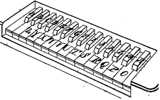

He saw the Hughes-Phelps printing telegraph there. Its keyboard looked like a piano, arranging A to N left to right and O to Z right to left (shown right, taken from [U. S. Patent No.26003](http://patimg1.uspto.gov/.piw?docid=00026003&IDKey=NONE)). Mr. Sholes adopted a piano-like keyboard in his Type-Writing Machine, in which he could place but twenty-one keys ([U. S. Patent No.79265](http://patimg2.uspto.gov/.piw?docid=00079265&IDKey=NONE)) and later twenty-eight keys (cf. *"Writing by Machinery", Milwaukee Daily Sentinel, Vol.26, No.236 (October 6, 1869), p.1, l.4*). He changed the keys into button-like ones in April of 1870 (cf. *Chas. E. Weller: The Early History of the Typewriter, La Porte (1921)*) when he invented a new Type-Writer with a four-row keyboard, in which each row consisted of ten or eleven keys ([U. S. Patent No.182511](http://patimg1.uspto.gov/.piw?docid=00182511&IDKey=NONE) but it has only three rows). In his new model Mr. Sholes moved vowels to the upper row of the keyboard in order to put the twenty-six letters in ten columns (shown below, taken from *Koichi Yasuoka: "QWERTY Revisited", Journal of Information Processing and Management, Vol.48, No.2 (May 2005), pp.115-118*). This is the origin of QWERTY.

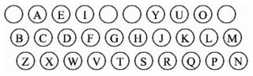

*posted by Koichi Yasuoka at [10:51 PM](http://yasuoka.blogspot.com/2006/08/printing-telegraphic-dispatches.html)* [0 comments](https://www.blogger.com/comment/fullpage/post/31607099/115461362396896577)

## Tuesday, August 01, 2006

> Sholes discovered that many English words contained combinations of letters next to each other in the alphabet. ... His solution was as simple as it was ingenious: move common letter-pairs away from each other. He went about the task in a scientific way. He got the educator Amos Densmore (his sponsor's brother) to prepare a frequency study of letter-pairs in the English language. He then used the study to split up as many common letter-combinations as he could and scatter them across his keyboard. When he was finished, the result was the alphabet soup that is the QWERTY keyboard. -- *Torbjörn Lundmark: Quirky QWERTY, University of New South Wales Press, Sydney (2002).*

Wrong. The most common letter-pair in English words is "th", which is placed adjacently in the QWERTY keyboard. The second is "er" + "re", also placed in the neighborhood of one another. They never stay away in the QWERTY keyboard. Mr. Lundmark's story does not tell the truth of QWERTY.

Additionally, Mr. Amos Densmore was not an educator at that time in 1860's. He was then a proprietor of Densmore Oil Company at Meadville, Pennsylvania, which manufactured train cars for transporting petroleum (cf. [U. S. Patent No.53794](http://patimg2.uspto.gov/.piw?docid=00053794&IDKey=NONE)).

*posted by Koichi Yasuoka at [4:10 PM](http://yasuoka.blogspot.com/2006/08/sholes-discovered-that-many-english.html)* [2 comments](https://www.blogger.com/comment/fullpage/post/31607099/115441959056744490)

## Wednesday, July 26, 2006

> So it begins only little more than a century ago, with the fifty-second man to invent the typewriter. Christopher Latham Sholes was a Milwaukee, Wisconsin printer by trade, and a mechanical tinkerer by inclination. Helped by his friends, Carlos Glidden and Samuel W. Soule, he had built a primitive writing machine for which a patent application was filed in October 1867. -- *Paul A. David: "Clio and the Economics of QWERTY", The American Economic Review, Vol.75, No.2 (May 1985), pp.332-337.*

A printer? Mr. Christopher Latham Sholes was? No. He occupied the government position of Collector of the Port of Milwaukee at that time in 1867 (cf. *"Removal of Collector Sholes", Milwaukee Daily Sentinel, Vol.24, No.247 (October 26, 1867), p.1, l.6*). He was one of the first Senators of Wisconsin in 1848, and an editor of Wisconsin newspapers including Southport Telegraph, Kenosha Telegraph, Kenosha Tribune & Telegraph, Free Democrat, Milwaukee Daily News, and Milwaukee Daily Sentinel. He might have occupied himself in printing in 1840's, but he seems to have quit it after the scandal on printing the Revised Statutes in 1849 (cf. *"The Printing Job", Milwaukee Sentinel and Gazette, Vol.4, No.302 (April 7, 1849), p.2, l.3*).

*posted by Koichi Yasuoka at [9:30 PM](http://yasuoka.blogspot.com/2006/07/so-it-begins-only-little-more-than.html)* [0 comments](https://www.blogger.com/comment/fullpage/post/31607099/115391894751314946)